# Adaptive Designs in Public Health: Vaccine and Cluster Randomized Trials go Bayesian

Ofir Harari, Jay J. H. Park, Prince Kumar Lat & Edward J. Mills

April 5, 2024

The following tutorial is a step-by-step demo of the methods presented in [our paper](https://onlinelibrary.wiley.com/doi/10.1002/sim.10104). You may use [our code](https://github.com/oharari/Bayesian-Adaptive-Public-Health-Designs/tree/main/Code) to reproduce the below results or experiment with it.

# 1 Before we start

Make sure that the following libraries are installed on your computer –

```r
library(ggplot2)
library(gridExtra)
library(foreach)
library(tcltk)
library(rlecuyer)
library(tictoc)
library(lemon)
library(scales)
library(dplyr)
library(knitr)
library(kableExtra)
library(magick)
library(gtools)
library(data.table)
library(doParallel)
library(doSNOW)
library(snow)
library(foreach)
library(tidyverse)
library(reshape2)
library(pracma)
library(paletteer)
library(grDevices)
```

Setting the working directory and sourcing the custom functions –

```r
#Setting working directory to current one
setwd(dirname(rstudioapi::getActiveDocumentContext()$path))

# Sourcing functions
source('Vaccine_Trial_Functions.R')
source('Negative_Binomial_Functions.R')
```

# 2 Bayesian multi-arm, multi-stage vaccine trials

We start by replicating the results presented in Section 2 of our manuscript. The idea is to design a 4-arm (three vaccine arms and a placebo arm) adaptive trial with a maximum number of four analyses and a $\rho:1:1:1$ randomization ratio, where $\rho$ is the control/treatment ratio derived to minimize the D-optimality criterion, that is: the determinant of the covariance matrix of the contrast estimate $\hat{\boldsymbol{c}}$, contrasting each treatment event rate with the common control event rate.

To do so, we need to provide the number of active vaccine arms (in this case 3) and guestimates for the control event rate (here we use 5%), the treatment relative rate reduction (37.5%).

## 2.1 Calculating the optimal allocation ratio

```r
D_opt = D_optimal_alloc_ratio(p_ctrl = .05, n_trts = 3, RRR = .375)
D_opt$rho
```

```
## [1] 1.108459
```

It turns out that the optimal allocation ratio (according to our inputs) is 1.11:1:1:1.

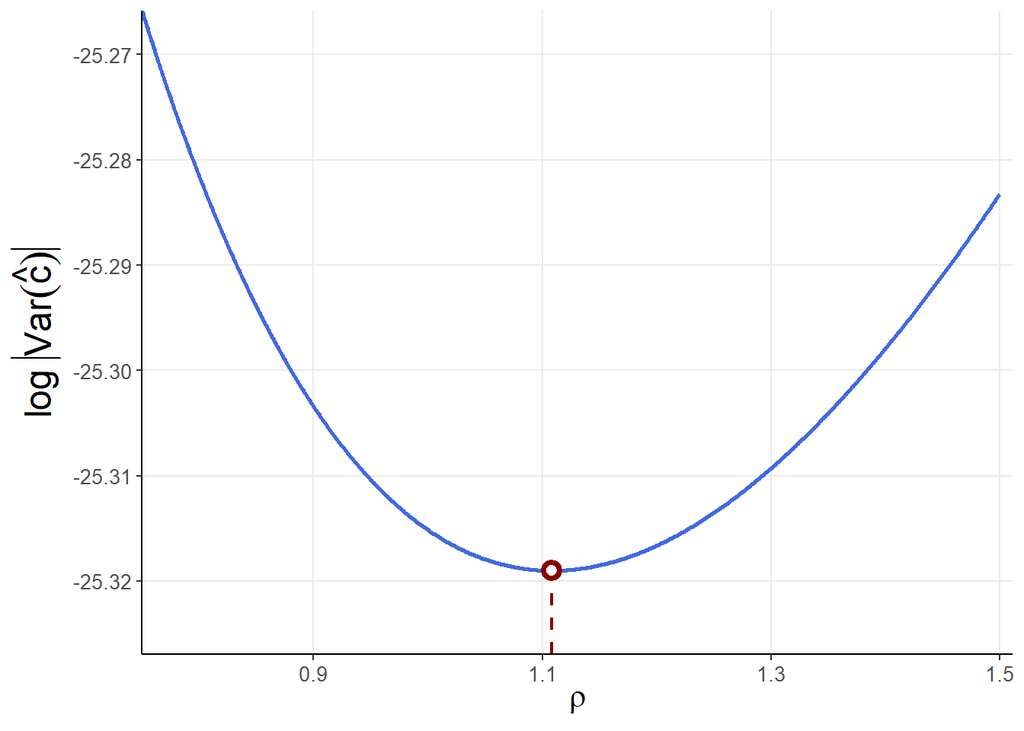

```r
D_opt$plot
```

## 2.2 Prior selection

The first step would be selecting a Dirichlet prior distribution for the transformed vaccine effects. The following inputs are required –

```r
ratio = D_opt$rho
q = 1/(1 + ratio) # the (normalized) allocation probability to vaccine
alpha_trt = c(1, 2, 5, 15) # Vaccine Dirichlet hyperparameters to explore
```

For every vaccine hyperparameter of choice, we match a placebo hyperparameter to ensure a 50% a priori probability of efficacy –

```r
alpha_ctrl = sapply(alpha_trt, alpha_ctrl_func, q = q)
alpha = cbind(alpha_trt, alpha_ctrl)
```

This results in the following table –

```r
priors = do.call(rbind,
                 apply(alpha, 1, VE_prior_summary, q = q)
)

priors %>%
  kbl(align = 'c', escape = F) %>%
  kable_styling(full_width = F,
                bootstrap_options = c("striped"))
```

| $\alpha_{\mathrm{vax}}$ | $\alpha_{\mathrm{ctrl}}$ | Mean | Median | 95% CrI |
| --- | --- | --- | --- | --- |
| 1.00 | 1.08 | -13.21 | 0.00 | [-31.84; 0.97] |
| 2.00 | 2.18 | -0.87 | 0.00 | [-7.73; 0.89] |
| 5.00 | 5.51 | -0.23 | 0.00 | [-2.55; 0.73] |
| 15.00 | 16.59 | -0.07 | 0.00 | [-1.03; 0.51] |

Visually, these are the different priors –

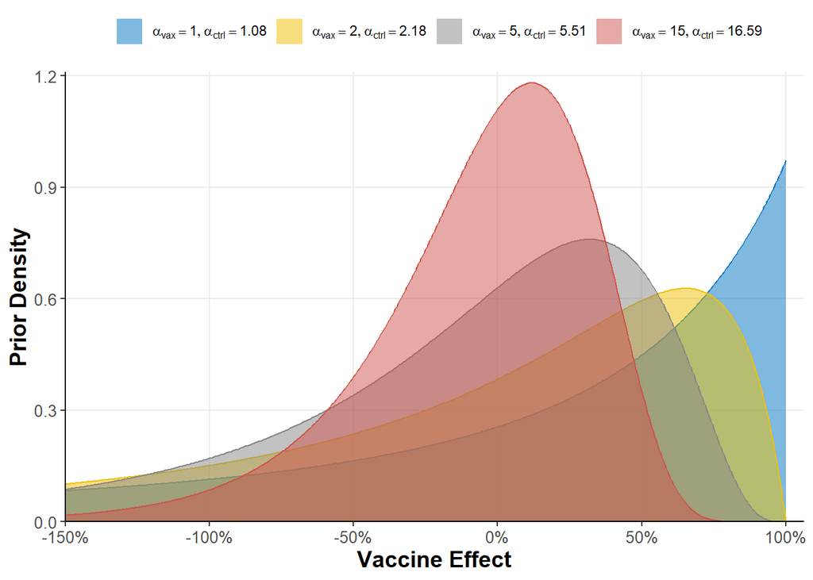

```r
LL = -1.5
UL = 1
delta = 5e-3

VE_prior_1D_density_plot(LL, UL, delta, alpha, trt_prob = q)
```

## 2.3 Trial design

```r
VE = c(.5, .375, .25) # vaccine effects
d = length(VE) # number of vaccines
trt_prob = 1/(d + ratio) # vaccine allocation probability
ctrl_prob = ratio*trt_prob # control allocation probability
alloc_probs = c(ctrl_prob, rep(trt_prob, d))
n_analyses = 4 # number of analyses (including final)
effic_thresh = rep(.99015, n_analyses) # efficacy threshold vector
futil_thresh = c(.25, .5, .75, 1) # futility threshold vector

# number of events per remaining arm to trigger an interim analysis
N_events_per_arm_per_analysis = 10
# Dirichlet prior hyperparameters: (vaccine, control)
hyperpar = c(1, 1.078011)
```

### 2.3.1 Sample trial

Let us now see what a random trial looks like, under the assumptions and the decision rules stated above –

```r
LL = -1.1 # lower x-axis limit
UL = .9 # upper x-axis limit
delta = 5e-3 # grid resolution

trial = vaccine_trial_plots_and_table(N_events_per_arm_per_analysis, VE,
                                      n_analyses, alloc_probs, hyperpar,
                                      futil_thresh, effic_thresh, LL, UL,
                                      delta, seed = 39)
```

The resultant object is a list with multiple slots. The first one is a plot displaying the posterior probability of efficacy of each vaccine over time –

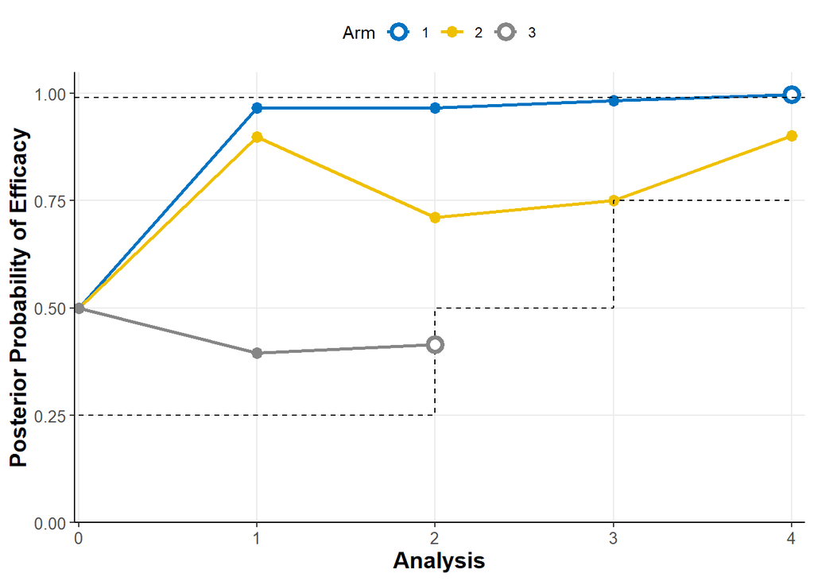

```r
trial$p_post_effic
```

### 2.3.2 Posterior inference

Another slot the trial object contains is a summary table that details the cases attributed to each arm over time, along with some Bayesian inference that is based on the posterior VE distribution –

```r
trial$sum_tab %>%
  kbl(align = 'c') %>%
  kable_styling(full_width = F, font_size = 11,
                bootstrap_options = c("striped"))
```

| Arm | Stopping reason | Analysis 1 cases | Analysis 2 cases | Analysis 3 cases | Analysis 4 cases | Efficacy | Pr(Efficacy\|Data) | VE [95% CrI] |
| --- | --- | --- | --- | --- | --- | --- | --- | --- |
| Control |  | 14 | 25 | 38 | 54 |  |  |  |
| 1 | End of trial | 5 | 12 | 19 | 25 | Yes | 99.8% | 48.0% [17.9%; 68.0%] |
| 2 | End of trial | 7 | 19 | 29 | 37 | No | 90.1% | 23.7% [-15.0%; 50.0%] |
| 3 | Early futility | 14 | 24 |  |  | No | 41.5% | -6.2% [-84.8%; 39.1%] |

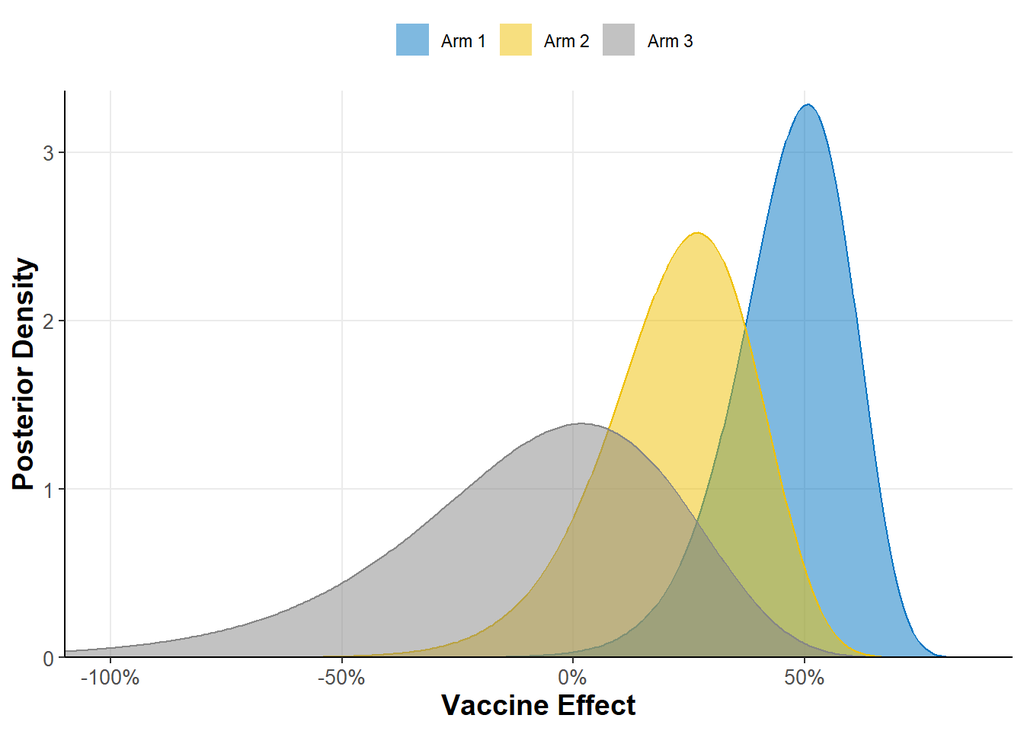

```r
trial$VE_post_plot
```

Note that the third vaccine was stopped after merely two analyses, and its VE’s distribution is thus more diffuse.

### 2.3.3 Operating characteristics

To evaluate some long run, frequenties properties of the proposed design, we run 100,000 simulations like the one above and collect certain statistics –

```r
full_sim = full_vaccine_trial_simulation(N_simulations = 1e5,
                                         N_events_per_arm_per_analysis,
                                         VE, n_analyses,
                                         alloc_probs, hyperpar,
                                         futil_thresh, effic_thresh)
```

The above function includes two simulation runs: one other the alternative scenario $\mathrm{VE} = \left(50\%, 37.5\%, 25\%\right)$ and another one under the null scenario $\mathrm{VE} = \left(0\%, 0\%, 0\%\right)$. This yields the following table –

```r
full_sim$operating_chars %>%
  kbl(align = 'c', escape = F) %>%
  kable_styling(full_width = F,
                bootstrap_options = c("striped"))
```

| Arm | VE | Power | $\mathbb{P}(\mathrm{Stop} = 1)$ | $\mathbb{P}(\mathrm{Stop}\leq 2)$ | $\mathbb{P}(\mathrm{Stop}\leq 3)$ |
| --- | --- | --- | --- | --- | --- |
| All | 0% | 2.5% | 23.3% | 54.1% | 78.9% |
| 1 | 50% | 80.9% | 16.9% | 42.7% | 70.4% |
| 2 | 37.5% | 49.8% | 10.2% | 25.9% | 50.7% |
| 3 | 25% | 22.9% | 9.7% | 23.9% | 49.2% |

In this case, the decision boundaries were selected (through some trial-and-error) to yield the equivalents of a 2.5% one-sided type-I error rate and (at least) 80% power. You may also consider the early stopping probabilities under either scenario.

# 3 Bayesian adaptive cluster randomized trials

We now switch attention to the next section of the paper, where Bayesian cluster trials are discussed. Here, we explore the Gamma-Poisson mixture (negative binomial) model, where the use of beta conjugate priors facilitates the speed necessary for extensive simulations.

## 3.1 Prior selection

First, we look to choose the kind of beta prior for the transformed mean event rate parameters, $p_i$, that will make sense on the original $\mu$ scale. We start with plausible intracluster correlation coefficient (ICC) values of $\rho = 0.15$ and $\rho = 0.2$, and match the second beta shape parameter $b$ to a list of first shape parameters, $a$, in a way that would warrant that the mean event rate is centered at $10%$ for all arms a priori. All along, we assume an average cluster size of 50. The inputs are –

```r
# vector of intracluster correlation coefficient parameters to explore
ICC_vec = c(.15, .2)

# vector of mean event rate parameters prior means to explore
mu_mean_vec = c(.1)

# vector of beta prior first shape parameters to explore
beta_a_vec = c(2, 4, 8, 16)

#vector of mean cluster sizes to explore
n_vec = c(50)
```

and they lend themselves to the following summary table –

```r
priors = mu_prior_summary(beta_a_vec, n_vec, mu_mean_vec, ICC_vec)


priors %>%
  kbl(align = 'c', format = 'html') %>%
  kable_styling(full_width = F,
                bootstrap_options = c("striped", 'bordered')) %>%
  collapse_rows(columns = 1:3)
```

| $\mathbb{E}[\mu]$ | $\rho$ | $\phi$ | $(a,b)$ | 95% CrI |
| --- | --- | --- | --- | --- |
| 0.10 | 0.15 | 0.74 | $(2.00, 1.30)$ | [0.22%; 46.29%] |
|  |  |  | $(4.00, 1.59)$ | [0.70%; 48.32%] |
|  |  |  | $(8.00, 2.19)$ | [1.49%; 41.25%] |
|  |  |  | $(16.00, 3.37)$ | [2.56%; 31.67%] |
|  | 0.20 | 0.56 | $(2.00, 1.22)$ | [0.18%; 42.06%] |
|  |  |  | $(4.00, 1.44)$ | [0.56%; 48.23%] |
|  |  |  | $(8.00, 1.89)$ | [1.24%; 44.36%] |
|  |  |  | $(16.00, 2.78)$ | [2.21%; 35.14%] |

Visually, when the x-axis is displayed on the logarithmic scale, these are our prior candidates for $\rho = 0.15$ –

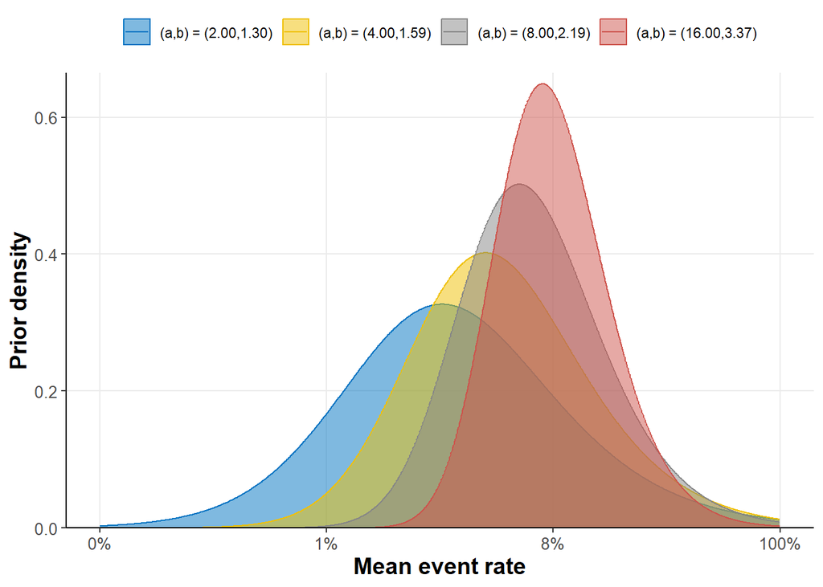

```r
mu_mean = .1
beta_a_vec = c(2, 4, 8, 16)
ICC = .15
mean_clust_size = 50
LL = 5e-4
UL = 1
delta = 5e-3

mu_prior_plot(mu_mean, beta_a_vec, ICC, mean_clust_size, LL, UL, delta)
```

Between those, we find the $\mathrm{Beta}(2.00, 1.30)$ prior to strike a good balance between information and a priori ambiguity.

## 3.2 Trial design

Let us take a peek at a single, randomly simulated trial. First, the required inputs are as follows –

```r
mean_clust_size = 50 # mean cluster size
ICC = .15 # intracluster correlation coefficient
mu_vec = c(.1, .075, .05) # mean event rate means
Trt_nms = c('A', 'B', 'C') # treatment arm names
N_clusts_max = 550 # maximum number of clusters
N_analyses = 3 # maximum number of analyses (including final)

# superiority threshold on the posterior probability of superiority
sup_thresh = .988

# futility threshold on the posterior probability of superiority
fut_thresh = .012

#first beta prior shape parameter
beta_a = 2

#second beta prior shape parameter
(beta_b = beta_prior_b_hyperpar(beta_a, mu_mean = .1, ICC, mean_clust_size))
```

```
## [1] 1.296296
```

### 3.2.1 Choosing shape parameters to match ICC

We also must provide values for the random effect shape parameters that will be used to generate random data. In the paper we show how to calculate those, based on the ICC –

```r
(true_phi_vec = ICC_to_shape(mu_vec, ICC))
```

```
## [1] 0.7407407 0.5405405 0.3508772
```

### 3.2.2 Sample trial

At long last, we may now simulate a random trial –

```r
set.seed(2)

simulation = single_cluster_trial_simulation(mu_vec, N_clusts_max,
                                             N_analyses,
                                             mean_clust_size,
                                             ICC, beta_a, beta_b,
                                             N_MC = 1e6, sup_thresh,
                                             fut_thresh)
```

To find out how things panned out, we look at the posterior probability of superiority trajectory of each arm –

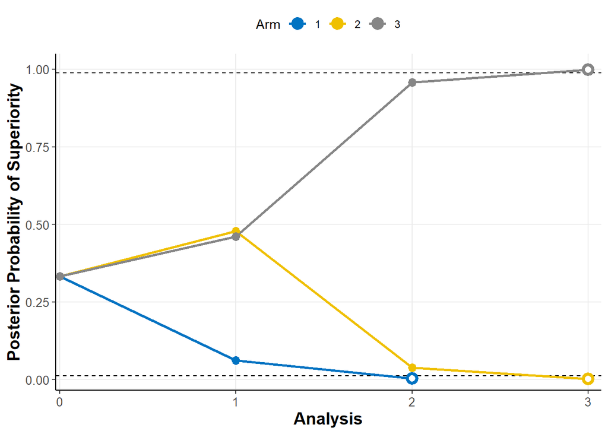

```r
cluster_prob_sup_plot(simulation, fut_thresh, sup_thresh)
```

We can see that the first arm was dropped after the second analysis for futility. The second and the third arm saw out the trial, at the end of which the third treatment was found to be the superior of the three.

### 3.2.3 Shape parameter plug-in values via empirical Bayes

To obtain closed form posterior distributions, we must supply values for the Gamma random effect shape parameter $\phi$. In the paper we derive empirical Bayes plug-in estimates by maximizing the arm-level log-marginal likelihood components –

```r
phi_vec = cluster_empirical_bayes_shape(simulation$data, beta_a, beta_b)
```

In this example, here is how they fare in estimating the true $\phi$ values used for generating the data –

```r
phi_vec
```

```
## [1] 0.6864255 0.5737721 0.3769163
```

```r
true_phi_vec
```

```
## [1] 0.7407407 0.5405405 0.3508772
```

and the log-marginal likelihood curves –

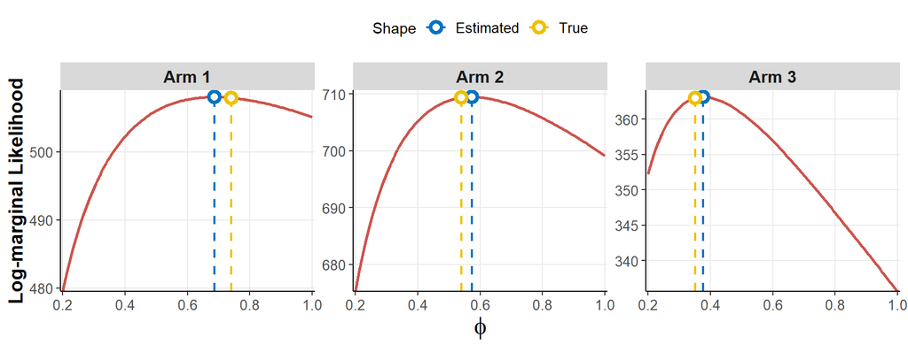

```r
LL = .2 # x-axis lower limit
UL = 1 # x-axis upper limit
delata = 1e-3 # grid resolution

cluster_marginal_likelihood_plot_all(simulation$data, beta_a, beta_b, true_phi_vec, LL, UL, delta)
```

### 3.2.4 Posterior inference

Everything is now set for Bayesian inference. Let us first examine the cumulative data in each arm by analysis, along with the eventual mean event rate (interval) estimate –

```r
single_trial_results = single_cluster_simulation_results(simulation, beta_a, beta_b)

single_trial_results %>%
  kbl(align = c(rep('c', 5), 'r'), escape = FALSE) %>%
  kable_styling(full_width = F, font_size = 12,
                bootstrap_options = c("striped")) %>%
  row_spec(0, align = 'c')
```

| Trt | Analysis 1 Clusters, Cases/Patients | Analysis 2 Clusters, Cases/Patients | Analysis 3 Clusters, Cases/Patients | Outcome | Mean event rate [95% CrI] |
| --- | --- | --- | --- | --- | --- |
| 1 | 62, 261/3075 | 123, 559/6203 |  | Early inferiority | 8.9% [7.2%; 11.3%] |
| 2 | 62, 202/3057 | 123, 469/6022 | 213, 844/10558 |  | 7.9% [6.6%; 9.6%] |
| 3 | 62, 206/3059 | 123, 341/6186 | 213, 582/10652 | Superiority | 5.4% [4.3%; 6.9%] |

and observe the posterior probability density functions of the different arms –

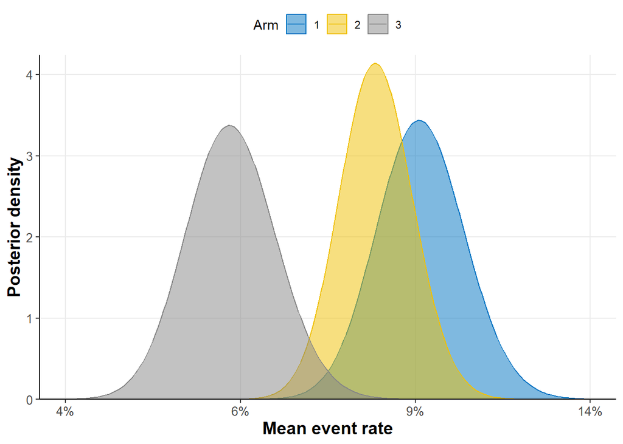

```r
LL = .035 # x-axis lower limit
UL = .14 # x-axis upper limit
delta = 5e-3 # grid resolution

cluster_post_density_plot(simulation, phi_vec, beta_a, beta_b, LL, UL, delta)
```

### 3.2.5 Operating characteristics

Finally, we simulate 100,000 random trials and collect statistics, to appraise the design –

```r
# each row in this matrix is a vector of mean event rates: one "alternative"
# scenario and two "null" scenarios
mu_matrix = matrix(c(.1, .075, .05,
                     .1, .1, .1,
                     .1, .05, .05),
                   ncol = 3, byrow = TRUE)

oper_charac = full_cluster_trial_simulation(mu_matrix, N_clusts_max,
                                            N_analyses, mean_clust_size,
                                            ICC, beta_a, beta_b,
                                            N_MC = 3e3, sup_thresh, fut_thresh,
                                            N_simulations = 1e5)
```

and the results are as follows –

```r
oper_charac %>%
  kbl(align = 'c', escape = FALSE) %>%
  kable_styling(full_width = F, bootstrap_options = c("striped"))
```

| Mean event rates | Mean no. of clusters | % of patients in Arm 1 | % of patients in Arm 2 | % of patients in Arm 3 | TPR | FPR |
| --- | --- | --- | --- | --- | --- | --- |
| (10.0%, 7.5%, 5.0%) | 412.1 | 20.9% | 38.8% | 40.3% | 80.6% | 0.0% |
| (10.0%, 10.0%, 10.0%) | 545.7 | 33.3% | 33.3% | 33.3% | – | 2.0% |
| (10.0%, 5.0%, 5.0%) | 532.0 | 13.0% | 43.5% | 43.5% | – | 9.7% |

# 4 References

1. Hayes RJ, Moulton LH. Cluster randomised trials. 2nd ed. New York, NY: Chapman; Hall/CRC; 2017.

2. Laurent, Stéphane, Legrand, Catherine. A bayesian framework for the ratio of two poisson rates in the context of vaccine efficacy trials. ESAIM: PS. 2012;16:375–98.

3. Senn S. The design and analysis of vaccine trials for COVID-19 for the purpose of estimating efficacy. Pharmaceutical Statistics. 2022;21:790–807.

4. Berry SM, Carlin BP, Lee JJ, Muller P. Bayesian adaptive methods for clinical trials. 1st ed. Boca Raton, FL: CRC Press; 2010.

5. Food and Drug Administration. Adaptive designs for clinical trials of drugs and biologics: Guidance for industry. 2019.

6. BioNTech/Pfizer. A phase 1/2/3, placebo-controlled, randomized, observer-blind, dose-finding study to evaluate the safety, tolerability, immunogenicity, and efficacy of SARS-cov-2 RNA vaccine candidates against covid-19 in healthy individuals. 2020.

7. Turner RM, Omar RZ, Thompson SG. Bayesian methods of analysis for cluster randomized trials with binary outcome data. Statistics in Medicine. 2001;20:453–72.

8. Shen J, Golchi S, Moodie EE, Benrimoh D. Bayesian group sequential designs for cluster-randomized trials. Stat. 2022;11:e487.

9. Casella G. An introduction to empirical bayes data analysis. The American Statistician. 1985;39:83–7.